# Risk Factor Analysis

## Outcome Variable

**Outcome Variable:** stunted

## Predictor Variables

**Intervention Variable:** exclfeed6

**Adjustment Set:**

unadjusted

## Stratifying Variables

The analysis was stratified on these variable(s):

- agecat
- studyid
- country

## Data Summary

| agecat | studyid | country | exclfeed6 | stunted | n_cell | n |
| --- | --- | --- | --- | --- | --- | --- |
| Birth | ki0047075b-MAL-ED | BANGLADESH | 0 | 0 | 146 | 231 |
| Birth | ki0047075b-MAL-ED | BANGLADESH | 0 | 1 | 29 | 231 |
| Birth | ki0047075b-MAL-ED | BANGLADESH | 1 | 0 | 46 | 231 |
| Birth | ki0047075b-MAL-ED | BANGLADESH | 1 | 1 | 10 | 231 |
| Birth | ki0047075b-MAL-ED | BRAZIL | 0 | 0 | 148 | 175 |
| Birth | ki0047075b-MAL-ED | BRAZIL | 0 | 1 | 15 | 175 |
| Birth | ki0047075b-MAL-ED | BRAZIL | 1 | 0 | 10 | 175 |
| Birth | ki0047075b-MAL-ED | BRAZIL | 1 | 1 | 2 | 175 |
| Birth | ki0047075b-MAL-ED | INDIA | 0 | 0 | 157 | 190 |
| Birth | ki0047075b-MAL-ED | INDIA | 0 | 1 | 28 | 190 |
| Birth | ki0047075b-MAL-ED | INDIA | 1 | 0 | 2 | 190 |
| Birth | ki0047075b-MAL-ED | INDIA | 1 | 1 | 3 | 190 |
| Birth | ki0047075b-MAL-ED | NEPAL | 0 | 0 | 141 | 170 |
| Birth | ki0047075b-MAL-ED | NEPAL | 0 | 1 | 18 | 170 |
| Birth | ki0047075b-MAL-ED | NEPAL | 1 | 0 | 11 | 170 |
| Birth | ki0047075b-MAL-ED | NEPAL | 1 | 1 | 0 | 170 |
| Birth | ki0047075b-MAL-ED | PERU | 0 | 0 | 219 | 256 |
| Birth | ki0047075b-MAL-ED | PERU | 0 | 1 | 27 | 256 |
| Birth | ki0047075b-MAL-ED | PERU | 1 | 0 | 8 | 256 |
| Birth | ki0047075b-MAL-ED | PERU | 1 | 1 | 2 | 256 |
| Birth | ki0047075b-MAL-ED | SOUTH AFRICA | 0 | 0 | 189 | 211 |
| Birth | ki0047075b-MAL-ED | SOUTH AFRICA | 0 | 1 | 22 | 211 |
| Birth | ki0047075b-MAL-ED | SOUTH AFRICA | 1 | 0 | 0 | 211 |
| Birth | ki0047075b-MAL-ED | SOUTH AFRICA | 1 | 1 | 0 | 211 |
| Birth | ki0047075b-MAL-ED | TANZANIA, UNITED REPUBLIC OF | 0 | 0 | 102 | 119 |
| Birth | ki0047075b-MAL-ED | TANZANIA, UNITED REPUBLIC OF | 0 | 1 | 16 | 119 |
| Birth | ki0047075b-MAL-ED | TANZANIA, UNITED REPUBLIC OF | 1 | 0 | 1 | 119 |
| Birth | ki0047075b-MAL-ED | TANZANIA, UNITED REPUBLIC OF | 1 | 1 | 0 | 119 |
| Birth | ki1000108-CMC-V-BCS-2002 | INDIA | 0 | 0 | 0 | 7 |
| Birth | ki1000108-CMC-V-BCS-2002 | INDIA | 0 | 1 | 0 | 7 |

[output cut: 158 more lines]

The following strata were considered:

- agecat: 24 months, studyid: ki0047075b-MAL-ED, country: BANGLADESH
- agecat: 24 months, studyid: ki0047075b-MAL-ED, country: BRAZIL
- agecat: 24 months, studyid: ki0047075b-MAL-ED, country: INDIA
- agecat: 24 months, studyid: ki0047075b-MAL-ED, country: NEPAL
- agecat: 24 months, studyid: ki0047075b-MAL-ED, country: PERU
- agecat: 24 months, studyid: ki0047075b-MAL-ED, country: SOUTH AFRICA
- agecat: 24 months, studyid: ki0047075b-MAL-ED, country: TANZANIA, UNITED REPUBLIC OF
- agecat: 24 months, studyid: ki1000108-CMC-V-BCS-2002, country: INDIA
- agecat: 24 months, studyid: ki1000108-IRC, country: INDIA
- agecat: 24 months, studyid: ki1017093b-PROVIDE, country: BANGLADESH
- agecat: 24 months, studyid: ki1101329-Keneba, country: GAMBIA
- agecat: 24 months, studyid: ki1113344-GMS-Nepal, country: NEPAL
- agecat: 24 months, studyid: ki1148112-LCNI-5, country: MALAWI
- agecat: 24 months, studyid: kiGH5241-JiVitA-3, country: BANGLADESH
- agecat: 24 months, studyid: kiGH5241-JiVitA-4, country: BANGLADESH
- agecat: 6 months, studyid: ki0047075b-MAL-ED, country: BANGLADESH
- agecat: 6 months, studyid: ki0047075b-MAL-ED, country: BRAZIL
- agecat: 6 months, studyid: ki0047075b-MAL-ED, country: INDIA
- agecat: 6 months, studyid: ki0047075b-MAL-ED, country: NEPAL
- agecat: 6 months, studyid: ki0047075b-MAL-ED, country: PERU
- agecat: 6 months, studyid: ki0047075b-MAL-ED, country: SOUTH AFRICA
- agecat: 6 months, studyid: ki0047075b-MAL-ED, country: TANZANIA, UNITED REPUBLIC OF
- agecat: 6 months, studyid: ki1000108-CMC-V-BCS-2002, country: INDIA
- agecat: 6 months, studyid: ki1000108-IRC, country: INDIA
- agecat: 6 months, studyid: ki1000109-EE, country: PAKISTAN
- agecat: 6 months, studyid: ki1000304b-SAS-CompFeed, country: INDIA
- agecat: 6 months, studyid: ki1000304b-SAS-FoodSuppl, country: INDIA
- agecat: 6 months, studyid: ki1017093b-PROVIDE, country: BANGLADESH
- agecat: 6 months, studyid: ki1101329-Keneba, country: GAMBIA
- agecat: 6 months, studyid: ki1113344-GMS-Nepal, country: NEPAL
- agecat: 6 months, studyid: ki1148112-LCNI-5, country: MALAWI
- agecat: 6 months, studyid: kiGH5241-JiVitA-3, country: BANGLADESH
- agecat: 6 months, studyid: kiGH5241-JiVitA-4, country: BANGLADESH
- agecat: Birth, studyid: ki0047075b-MAL-ED, country: BANGLADESH
- agecat: Birth, studyid: ki0047075b-MAL-ED, country: BRAZIL
- agecat: Birth, studyid: ki0047075b-MAL-ED, country: INDIA
- agecat: Birth, studyid: ki0047075b-MAL-ED, country: NEPAL
- agecat: Birth, studyid: ki0047075b-MAL-ED, country: PERU
- agecat: Birth, studyid: ki0047075b-MAL-ED, country: SOUTH AFRICA
- agecat: Birth, studyid: ki0047075b-MAL-ED, country: TANZANIA, UNITED REPUBLIC OF
- agecat: Birth, studyid: ki1000108-CMC-V-BCS-2002, country: INDIA
- agecat: Birth, studyid: ki1000108-IRC, country: INDIA
- agecat: Birth, studyid: ki1000109-EE, country: PAKISTAN
- agecat: Birth, studyid: ki1000304b-SAS-CompFeed, country: INDIA
- agecat: Birth, studyid: ki1101329-Keneba, country: GAMBIA
- agecat: Birth, studyid: kiGH5241-JiVitA-3, country: BANGLADESH
- agecat: Birth, studyid: kiGH5241-JiVitA-4, country: BANGLADESH

### Dropped Strata

Some strata were dropped due to rare outcomes:

- agecat: Birth, studyid: ki0047075b-MAL-ED, country: BRAZIL
- agecat: Birth, studyid: ki0047075b-MAL-ED, country: INDIA
- agecat: Birth, studyid: ki0047075b-MAL-ED, country: NEPAL
- agecat: Birth, studyid: ki0047075b-MAL-ED, country: PERU
- agecat: Birth, studyid: ki0047075b-MAL-ED, country: SOUTH AFRICA
- agecat: Birth, studyid: ki0047075b-MAL-ED, country: TANZANIA, UNITED REPUBLIC OF
- agecat: Birth, studyid: ki1000108-CMC-V-BCS-2002, country: INDIA
- agecat: Birth, studyid: ki1000108-IRC, country: INDIA
- agecat: Birth, studyid: ki1000109-EE, country: PAKISTAN
- agecat: Birth, studyid: ki1000304b-SAS-CompFeed, country: INDIA
- agecat: 6 months, studyid: ki0047075b-MAL-ED, country: BRAZIL
- agecat: 6 months, studyid: ki0047075b-MAL-ED, country: INDIA
- agecat: 6 months, studyid: ki0047075b-MAL-ED, country: NEPAL
- agecat: 6 months, studyid: ki0047075b-MAL-ED, country: PERU
- agecat: 6 months, studyid: ki0047075b-MAL-ED, country: SOUTH AFRICA
- agecat: 6 months, studyid: ki0047075b-MAL-ED, country: TANZANIA, UNITED REPUBLIC OF
- agecat: 6 months, studyid: ki1000108-CMC-V-BCS-2002, country: INDIA
- agecat: 6 months, studyid: ki1000108-IRC, country: INDIA
- agecat: 6 months, studyid: ki1000304b-SAS-FoodSuppl, country: INDIA
- agecat: 24 months, studyid: ki0047075b-MAL-ED, country: BRAZIL
- agecat: 24 months, studyid: ki0047075b-MAL-ED, country: INDIA
- agecat: 24 months, studyid: ki0047075b-MAL-ED, country: NEPAL
- agecat: 24 months, studyid: ki0047075b-MAL-ED, country: PERU
- agecat: 24 months, studyid: ki0047075b-MAL-ED, country: SOUTH AFRICA
- agecat: 24 months, studyid: ki0047075b-MAL-ED, country: TANZANIA, UNITED REPUBLIC OF
- agecat: 24 months, studyid: ki1000108-CMC-V-BCS-2002, country: INDIA
- agecat: 24 months, studyid: ki1000108-IRC, country: INDIA

## Methods Detail

We’re interested in the causal parameters $E[Y_a]$ for all values of $a \in \mathcal{A}$. These parameters represent the mean outcome if, possibly contrary to fact, we intervened to set all units to have $A=a$. Under the randomization and positivity assumptions, these are identified by the statistical parameters $\psi_a=E_W[E_{Y|A,W}(Y|A=a,W)]$. In addition, we’re interested in the mean of $Y$, $E[Y]$ under no intervention (the observed mean). We will estimate these parameters by using SuperLearner to fit the relevant likelihood factors – $E_{Y|A,W}(Y|A=a,W)$ and $p(A=a|W)$, and then updating our likelihood fit using a joint TMLE.

For unadjusted analyses ($W=\{\}$), initial likelihoods were estimated using Lrnr_glm to estimate the simple $E(Y|A)$ and Lrnr_mean to estimate $p(A)$. For adjusted analyses, a small library containing Lrnr_glmnet, Lrnr_xgboost, and Lrnr_mean was used.

Having estimated these parameters, we will then use the delta method to estimate relative risks and attributable risks relative to a prespecified baseline level of $A$.

# Results Detail

## Results Plots

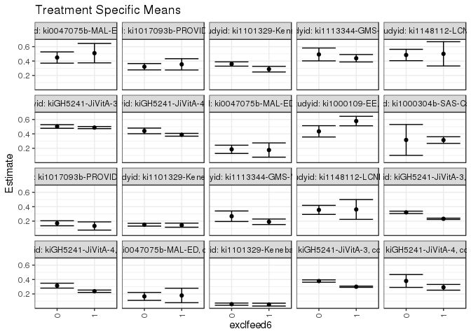

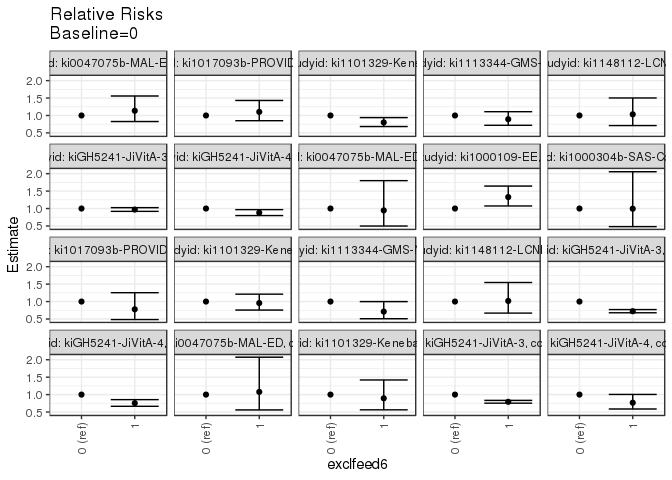

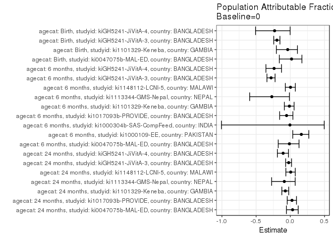

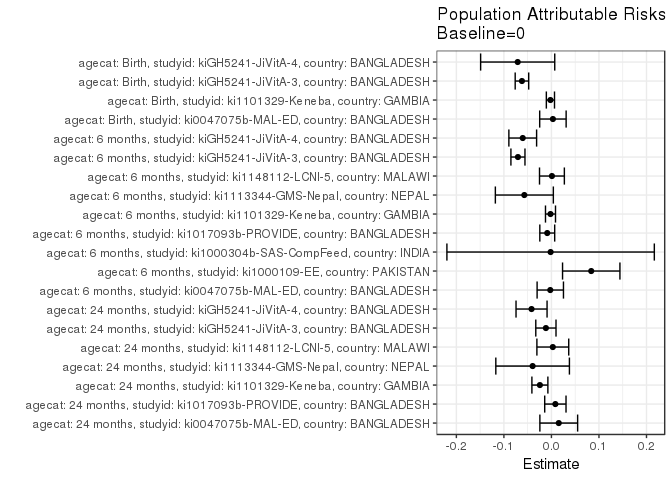

## Results Table

### Parameter: TSM

| agecat | studyid | country | intervention_level | baseline_level | estimate | ci_lower | ci_upper |
| --- | --- | --- | --- | --- | --- | --- | --- |
| Birth | ki0047075b-MAL-ED | BANGLADESH | 0 | NA | 0.1657143 | 0.1105055 | 0.2209231 |
| Birth | ki0047075b-MAL-ED | BANGLADESH | 1 | NA | 0.1785714 | 0.0780434 | 0.2790994 |
| Birth | ki1101329-Keneba | GAMBIA | 0 | NA | 0.0577972 | 0.0426879 | 0.0729065 |
| Birth | ki1101329-Keneba | GAMBIA | 1 | NA | 0.0516529 | 0.0319281 | 0.0713776 |
| Birth | kiGH5241-JiVitA-3 | BANGLADESH | 0 | NA | 0.3786746 | 0.3625201 | 0.3948292 |
| Birth | kiGH5241-JiVitA-3 | BANGLADESH | 1 | NA | 0.3001062 | 0.2916639 | 0.3085484 |
| Birth | kiGH5241-JiVitA-4 | BANGLADESH | 0 | NA | 0.3800000 | 0.2907817 | 0.4692183 |
| Birth | kiGH5241-JiVitA-4 | BANGLADESH | 1 | NA | 0.2917342 | 0.2520927 | 0.3313757 |
| 6 months | ki0047075b-MAL-ED | BANGLADESH | 0 | NA | 0.1853933 | 0.1281815 | 0.2426050 |
| 6 months | ki0047075b-MAL-ED | BANGLADESH | 1 | NA | 0.1754386 | 0.0764897 | 0.2743874 |
| 6 months | ki1000109-EE | PAKISTAN | 0 | NA | 0.4350649 | 0.3566591 | 0.5134708 |
| 6 months | ki1000109-EE | PAKISTAN | 1 | NA | 0.5779817 | 0.5123328 | 0.6436305 |
| 6 months | ki1000304b-SAS-CompFeed | INDIA | 0 | NA | 0.3157895 | 0.1014523 | 0.5301266 |
| 6 months | ki1000304b-SAS-CompFeed | INDIA | 1 | NA | 0.3139842 | 0.2679102 | 0.3600581 |
| 6 months | ki1017093b-PROVIDE | BANGLADESH | 0 | NA | 0.1700224 | 0.1351683 | 0.2048764 |
| 6 months | ki1017093b-PROVIDE | BANGLADESH | 1 | NA | 0.1323529 | 0.0753510 | 0.1893549 |
| 6 months | ki1101329-Keneba | GAMBIA | 0 | NA | 0.1497731 | 0.1305319 | 0.1690142 |
| 6 months | ki1101329-Keneba | GAMBIA | 1 | NA | 0.1433447 | 0.1149651 | 0.1717244 |
| 6 months | ki1113344-GMS-Nepal | NEPAL | 0 | NA | 0.2676056 | 0.1947233 | 0.3404879 |
| 6 months | ki1113344-GMS-Nepal | NEPAL | 1 | NA | 0.1905941 | 0.1522592 | 0.2289289 |
| 6 months | ki1148112-LCNI-5 | MALAWI | 0 | NA | 0.3555556 | 0.2928937 | 0.4182174 |
| 6 months | ki1148112-LCNI-5 | MALAWI | 1 | NA | 0.3617021 | 0.2240807 | 0.4993236 |
| 6 months | kiGH5241-JiVitA-3 | BANGLADESH | 0 | NA | 0.3212748 | 0.3043665 | 0.3381830 |
| 6 months | kiGH5241-JiVitA-3 | BANGLADESH | 1 | NA | 0.2322146 | 0.2231817 | 0.2412474 |
| 6 months | kiGH5241-JiVitA-4 | BANGLADESH | 0 | NA | 0.3148936 | 0.2808809 | 0.3489063 |
| 6 months | kiGH5241-JiVitA-4 | BANGLADESH | 1 | NA | 0.2374209 | 0.2210009 | 0.2538409 |
| 24 months | ki0047075b-MAL-ED | BANGLADESH | 0 | NA | 0.4487179 | 0.3704830 | 0.5269529 |
| 24 months | ki0047075b-MAL-ED | BANGLADESH | 1 | NA | 0.5094340 | 0.3745239 | 0.6443440 |
| 24 months | ki1017093b-PROVIDE | BANGLADESH | 0 | NA | 0.3210162 | 0.2770039 | 0.3650285 |
| 24 months | ki1017093b-PROVIDE | BANGLADESH | 1 | NA | 0.3541667 | 0.2759845 | 0.4323488 |
| 24 months | ki1101329-Keneba | GAMBIA | 0 | NA | 0.3587174 | 0.3289510 | 0.3884839 |
| 24 months | ki1101329-Keneba | GAMBIA | 1 | NA | 0.2873786 | 0.2482815 | 0.3264758 |
| 24 months | ki1113344-GMS-Nepal | NEPAL | 0 | NA | 0.4916667 | 0.4021261 | 0.5812073 |
| 24 months | ki1113344-GMS-Nepal | NEPAL | 1 | NA | 0.4388889 | 0.3875731 | 0.4902047 |
| 24 months | ki1148112-LCNI-5 | MALAWI | 0 | NA | 0.4838710 | 0.4049889 | 0.5627530 |
| 24 months | ki1148112-LCNI-5 | MALAWI | 1 | NA | 0.5000000 | 0.3314881 | 0.6685119 |
| 24 months | kiGH5241-JiVitA-3 | BANGLADESH | 0 | NA | 0.5023974 | 0.4774312 | 0.5273637 |
| 24 months | kiGH5241-JiVitA-3 | BANGLADESH | 1 | NA | 0.4874719 | 0.4729906 | 0.5019531 |
| 24 months | kiGH5241-JiVitA-4 | BANGLADESH | 0 | NA | 0.4409800 | 0.4018535 | 0.4801064 |
| 24 months | kiGH5241-JiVitA-4 | BANGLADESH | 1 | NA | 0.3876679 | 0.3679563 | 0.4073794 |

### Parameter: E(Y)

| agecat | studyid | country | intervention_level | baseline_level | estimate | ci_lower | ci_upper |
| --- | --- | --- | --- | --- | --- | --- | --- |
| Birth | ki0047075b-MAL-ED | BANGLADESH | NA | NA | 0.1688312 | 0.1204189 | 0.2172434 |
| Birth | ki1101329-Keneba | GAMBIA | NA | NA | 0.0556745 | 0.0436637 | 0.0676854 |
| Birth | kiGH5241-JiVitA-3 | BANGLADESH | NA | NA | 0.3166335 | 0.3090239 | 0.3242430 |
| Birth | kiGH5241-JiVitA-4 | BANGLADESH | NA | NA | 0.3089961 | 0.2722361 | 0.3457561 |
| 6 months | ki0047075b-MAL-ED | BANGLADESH | NA | NA | 0.1829787 | 0.1334386 | 0.2325189 |
| 6 months | ki1000109-EE | PAKISTAN | NA | NA | 0.5188172 | 0.4679751 | 0.5696593 |
| 6 months | ki1000304b-SAS-CompFeed | INDIA | NA | NA | 0.3140704 | 0.2712850 | 0.3568557 |
| 6 months | ki1017093b-PROVIDE | BANGLADESH | NA | NA | 0.1612350 | 0.1313580 | 0.1911120 |
| 6 months | ki1101329-Keneba | GAMBIA | NA | NA | 0.1477987 | 0.1318701 | 0.1637274 |
| 6 months | ki1113344-GMS-Nepal | NEPAL | NA | NA | 0.2106227 | 0.1763897 | 0.2448557 |
| 6 months | ki1148112-LCNI-5 | MALAWI | NA | NA | 0.3566176 | 0.2995882 | 0.4136471 |
| 6 months | kiGH5241-JiVitA-3 | BANGLADESH | NA | NA | 0.2508093 | 0.2426385 | 0.2589801 |
| 6 months | kiGH5241-JiVitA-4 | BANGLADESH | NA | NA | 0.2545198 | 0.2394884 | 0.2695513 |
| 24 months | ki0047075b-MAL-ED | BANGLADESH | NA | NA | 0.4641148 | 0.3963405 | 0.5318891 |
| 24 months | ki1017093b-PROVIDE | BANGLADESH | NA | NA | 0.3292894 | 0.2909105 | 0.3676684 |
| 24 months | ki1101329-Keneba | GAMBIA | NA | NA | 0.3344349 | 0.3106543 | 0.3582155 |
| 24 months | ki1113344-GMS-Nepal | NEPAL | NA | NA | 0.4520833 | 0.4075129 | 0.4966538 |
| 24 months | ki1148112-LCNI-5 | MALAWI | NA | NA | 0.4867725 | 0.4153250 | 0.5582200 |
| 24 months | kiGH5241-JiVitA-3 | BANGLADESH | NA | NA | 0.4907516 | 0.4775997 | 0.5039035 |
| 24 months | kiGH5241-JiVitA-4 | BANGLADESH | NA | NA | 0.3991375 | 0.3806098 | 0.4176653 |

### Parameter: RR

| agecat | studyid | country | intervention_level | baseline_level | estimate | ci_lower | ci_upper |
| --- | --- | --- | --- | --- | --- | --- | --- |
| Birth | ki0047075b-MAL-ED | BANGLADESH | 0 | 0 | 1.0000000 | 1.0000000 | 1.0000000 |
| Birth | ki0047075b-MAL-ED | BANGLADESH | 1 | 0 | 1.0775863 | 0.5602190 | 2.0727469 |
| Birth | ki1101329-Keneba | GAMBIA | 0 | 0 | 1.0000000 | 1.0000000 | 1.0000000 |
| Birth | ki1101329-Keneba | GAMBIA | 1 | 0 | 0.8936925 | 0.5626071 | 1.4196164 |
| Birth | kiGH5241-JiVitA-3 | BANGLADESH | 0 | 0 | 1.0000000 | 1.0000000 | 1.0000000 |
| Birth | kiGH5241-JiVitA-3 | BANGLADESH | 1 | 0 | 0.7925173 | 0.7536421 | 0.8333977 |
| Birth | kiGH5241-JiVitA-4 | BANGLADESH | 0 | 0 | 1.0000000 | 1.0000000 | 1.0000000 |
| Birth | kiGH5241-JiVitA-4 | BANGLADESH | 1 | 0 | 0.7677216 | 0.5867509 | 1.0045087 |
| 6 months | ki0047075b-MAL-ED | BANGLADESH | 0 | 0 | 1.0000000 | 1.0000000 | 1.0000000 |
| 6 months | ki0047075b-MAL-ED | BANGLADESH | 1 | 0 | 0.9463052 | 0.4975280 | 1.7998854 |
| 6 months | ki1000109-EE | PAKISTAN | 0 | 0 | 1.0000000 | 1.0000000 | 1.0000000 |
| 6 months | ki1000109-EE | PAKISTAN | 1 | 0 | 1.3284951 | 1.0736062 | 1.6438983 |
| 6 months | ki1000304b-SAS-CompFeed | INDIA | 0 | 0 | 1.0000000 | 1.0000000 | 1.0000000 |
| 6 months | ki1000304b-SAS-CompFeed | INDIA | 1 | 0 | 0.9942832 | 0.4810773 | 2.0549693 |
| 6 months | ki1017093b-PROVIDE | BANGLADESH | 0 | 0 | 1.0000000 | 1.0000000 | 1.0000000 |
| 6 months | ki1017093b-PROVIDE | BANGLADESH | 1 | 0 | 0.7784443 | 0.4831451 | 1.2542308 |
| 6 months | ki1101329-Keneba | GAMBIA | 0 | 0 | 1.0000000 | 1.0000000 | 1.0000000 |
| 6 months | ki1101329-Keneba | GAMBIA | 1 | 0 | 0.9570793 | 0.7558748 | 1.2118420 |
| 6 months | ki1113344-GMS-Nepal | NEPAL | 0 | 0 | 1.0000000 | 1.0000000 | 1.0000000 |
| 6 months | ki1113344-GMS-Nepal | NEPAL | 1 | 0 | 0.7122199 | 0.5076630 | 0.9992007 |
| 6 months | ki1148112-LCNI-5 | MALAWI | 0 | 0 | 1.0000000 | 1.0000000 | 1.0000000 |
| 6 months | ki1148112-LCNI-5 | MALAWI | 1 | 0 | 1.0172872 | 0.6688622 | 1.5472145 |
| 6 months | kiGH5241-JiVitA-3 | BANGLADESH | 0 | 0 | 1.0000000 | 1.0000000 | 1.0000000 |
| 6 months | kiGH5241-JiVitA-3 | BANGLADESH | 1 | 0 | 0.7227912 | 0.6784233 | 0.7700607 |
| 6 months | kiGH5241-JiVitA-4 | BANGLADESH | 0 | 0 | 1.0000000 | 1.0000000 | 1.0000000 |
| 6 months | kiGH5241-JiVitA-4 | BANGLADESH | 1 | 0 | 0.7539718 | 0.6644513 | 0.8555533 |
| 24 months | ki0047075b-MAL-ED | BANGLADESH | 0 | 0 | 1.0000000 | 1.0000000 | 1.0000000 |
| 24 months | ki0047075b-MAL-ED | BANGLADESH | 1 | 0 | 1.1353100 | 0.8268275 | 1.5588847 |
| 24 months | ki1017093b-PROVIDE | BANGLADESH | 0 | 0 | 1.0000000 | 1.0000000 | 1.0000000 |
| 24 months | ki1017093b-PROVIDE | BANGLADESH | 1 | 0 | 1.1032674 | 0.8507945 | 1.4306615 |
| 24 months | ki1101329-Keneba | GAMBIA | 0 | 0 | 1.0000000 | 1.0000000 | 1.0000000 |
| 24 months | ki1101329-Keneba | GAMBIA | 1 | 0 | 0.8011282 | 0.6831156 | 0.9395282 |
| 24 months | ki1113344-GMS-Nepal | NEPAL | 0 | 0 | 1.0000000 | 1.0000000 | 1.0000000 |
| 24 months | ki1113344-GMS-Nepal | NEPAL | 1 | 0 | 0.8926554 | 0.7189426 | 1.1083411 |
| 24 months | ki1148112-LCNI-5 | MALAWI | 0 | 0 | 1.0000000 | 1.0000000 | 1.0000000 |
| 24 months | ki1148112-LCNI-5 | MALAWI | 1 | 0 | 1.0333333 | 0.7106383 | 1.5025615 |
| 24 months | kiGH5241-JiVitA-3 | BANGLADESH | 0 | 0 | 1.0000000 | 1.0000000 | 1.0000000 |
| 24 months | kiGH5241-JiVitA-3 | BANGLADESH | 1 | 0 | 0.9702913 | 0.9187251 | 1.0247518 |
| 24 months | kiGH5241-JiVitA-4 | BANGLADESH | 0 | 0 | 1.0000000 | 1.0000000 | 1.0000000 |
| 24 months | kiGH5241-JiVitA-4 | BANGLADESH | 1 | 0 | 0.8791055 | 0.7984298 | 0.9679328 |

### Parameter: PAR

| agecat | studyid | country | intervention_level | baseline_level | estimate | ci_lower | ci_upper |
| --- | --- | --- | --- | --- | --- | --- | --- |
| Birth | ki0047075b-MAL-ED | BANGLADESH | 0 | NA | 0.0031169 | -0.0246960 | 0.0309297 |
| Birth | ki1101329-Keneba | GAMBIA | 0 | NA | -0.0021226 | -0.0107077 | 0.0064624 |
| Birth | kiGH5241-JiVitA-3 | BANGLADESH | 0 | NA | -0.0620412 | -0.0762548 | -0.0478275 |
| Birth | kiGH5241-JiVitA-4 | BANGLADESH | 0 | NA | -0.0710039 | -0.1489667 | 0.0069589 |
| 6 months | ki0047075b-MAL-ED | BANGLADESH | 0 | NA | -0.0024145 | -0.0301433 | 0.0253142 |
| 6 months | ki1000109-EE | PAKISTAN | 0 | NA | 0.0837523 | 0.0233987 | 0.1441058 |
| 6 months | ki1000304b-SAS-CompFeed | INDIA | 0 | NA | -0.0017191 | -0.2199177 | 0.2164795 |
| 6 months | ki1017093b-PROVIDE | BANGLADESH | 0 | NA | -0.0087874 | -0.0244270 | 0.0068522 |
| 6 months | ki1101329-Keneba | GAMBIA | 0 | NA | -0.0019743 | -0.0125058 | 0.0085571 |
| 6 months | ki1113344-GMS-Nepal | NEPAL | 0 | NA | -0.0569829 | -0.1179813 | 0.0040154 |
| 6 months | ki1148112-LCNI-5 | MALAWI | 0 | NA | 0.0010621 | -0.0250685 | 0.0271927 |
| 6 months | kiGH5241-JiVitA-3 | BANGLADESH | 0 | NA | -0.0704655 | -0.0852478 | -0.0556832 |
| 6 months | kiGH5241-JiVitA-4 | BANGLADESH | 0 | NA | -0.0603738 | -0.0895456 | -0.0312020 |
| 24 months | ki0047075b-MAL-ED | BANGLADESH | 0 | NA | 0.0153969 | -0.0243137 | 0.0551074 |
| 24 months | ki1017093b-PROVIDE | BANGLADESH | 0 | NA | 0.0082733 | -0.0141483 | 0.0306948 |
| 24 months | ki1101329-Keneba | GAMBIA | 0 | NA | -0.0242825 | -0.0410951 | -0.0074699 |
| 24 months | ki1113344-GMS-Nepal | NEPAL | 0 | NA | -0.0395833 | -0.1170125 | 0.0378459 |
| 24 months | ki1148112-LCNI-5 | MALAWI | 0 | NA | 0.0029015 | -0.0305815 | 0.0363845 |
| 24 months | kiGH5241-JiVitA-3 | BANGLADESH | 0 | NA | -0.0116459 | -0.0329197 | 0.0096280 |
| 24 months | kiGH5241-JiVitA-4 | BANGLADESH | 0 | NA | -0.0418424 | -0.0744912 | -0.0091937 |

### Parameter: PAF

| agecat | studyid | country | intervention_level | baseline_level | estimate | ci_lower | ci_upper |
| --- | --- | --- | --- | --- | --- | --- | --- |
| Birth | ki0047075b-MAL-ED | BANGLADESH | 0 | NA | 0.0184616 | -0.1608471 | 0.1700735 |
| Birth | ki1101329-Keneba | GAMBIA | 0 | NA | -0.0381260 | -0.2041448 | 0.1050033 |
| Birth | kiGH5241-JiVitA-3 | BANGLADESH | 0 | NA | -0.1959400 | -0.2419156 | -0.1516664 |
| Birth | kiGH5241-JiVitA-4 | BANGLADESH | 0 | NA | -0.2297890 | -0.5085567 | -0.0025351 |
| 6 months | ki0047075b-MAL-ED | BANGLADESH | 0 | NA | -0.0131957 | -0.1766295 | 0.1275371 |
| 6 months | ki1000109-EE | PAKISTAN | 0 | NA | 0.1614292 | 0.0356493 | 0.2708037 |
| 6 months | ki1000304b-SAS-CompFeed | INDIA | 0 | NA | -0.0054737 | -1.0068383 | 0.4962338 |
| 6 months | ki1017093b-PROVIDE | BANGLADESH | 0 | NA | -0.0545005 | -0.1557574 | 0.0378853 |
| 6 months | ki1101329-Keneba | GAMBIA | 0 | NA | -0.0133582 | -0.0871685 | 0.0554409 |
| 6 months | ki1113344-GMS-Nepal | NEPAL | 0 | NA | -0.2705450 | -0.5944671 | -0.0124289 |
| 6 months | ki1148112-LCNI-5 | MALAWI | 0 | NA | 0.0029782 | -0.0730552 | 0.0736242 |
| 6 months | kiGH5241-JiVitA-3 | BANGLADESH | 0 | NA | -0.2809526 | -0.3419840 | -0.2226968 |
| 6 months | kiGH5241-JiVitA-4 | BANGLADESH | 0 | NA | -0.2372066 | -0.3568361 | -0.1281245 |
| 24 months | ki0047075b-MAL-ED | BANGLADESH | 0 | NA | 0.0331747 | -0.0563885 | 0.1151445 |
| 24 months | ki1017093b-PROVIDE | BANGLADESH | 0 | NA | 0.0251246 | -0.0453975 | 0.0908893 |
| 24 months | ki1101329-Keneba | GAMBIA | 0 | NA | -0.0726077 | -0.1240977 | -0.0234762 |
| 24 months | ki1113344-GMS-Nepal | NEPAL | 0 | NA | -0.0875576 | -0.2732548 | 0.0710567 |
| 24 months | ki1148112-LCNI-5 | MALAWI | 0 | NA | 0.0059607 | -0.0652660 | 0.0724250 |
| 24 months | kiGH5241-JiVitA-3 | BANGLADESH | 0 | NA | -0.0237307 | -0.0680186 | 0.0187208 |
| 24 months | kiGH5241-JiVitA-4 | BANGLADESH | 0 | NA | -0.1048321 | -0.1893628 | -0.0263093 |